## Peer Grader Guidance

Please review the student expectations for peer review grading and peer review comments. Overall, we ask that you score with accuracy. When grading your peers, you will not only learn how to improve your future homework submissions but you will also gain deeper understanding of the concepts in the assignments. When assigning scores, consider the responses to the questions given your understanding of the problem and using the solutions as a guide. Moreover, please give partial credit for a concerted effort, but also be thorough. **Add comments to your review, particularly when deducting points, to explain why the student missed the points.** Ensure your comments are specific to questions and the student responses in the assignment.

# Background

You have been contracted as a healthcare consulting company to understand the factors on which the pricing of health insurance depends.

## Data Description

The data consists of a data frame with 1338 observations on the following 7 variables:

1. price: Response variable ($)
2. age: Quantitative variable
3. sex: Qualitative variable
4. bmi: Quantitative variable
5. children: Quantitative variable
6. smoker: Qualitative variable
7. region: Qualitative variable

## Instructions on reading the data

To read the data in `R`, save the file in your working directory (make sure you have changed the directory if different from the R working directory) and read the data using the `R` function `read.csv()`

```r
setwd("E:/Data")
insurance = read.csv("insurance.csv", head = TRUE)
head(insurance)
```

```
##   age    sex    bmi children smoker    region     price
## 1  19 female 27.900        0    yes southwest 16884.924
## 2  18   male 33.770        1     no southeast  1725.552
## 3  28   male 33.000        3     no southeast  4449.462
## 4  33   male 22.705        0     no northwest 21984.471
## 5  32   male 28.880        0     no northwest  3866.855
## 6  31 female 25.740        0     no southeast  3756.622
```

# Question 1: Exploratory Data Analysis [15 points]

1. **4 pts** Create scatterplots of the response, *price*, against three quantitative predictors *age*, *bmi*, and *children*. Describe the general trend (direction and form) of each plot. It should be 3 separate scatter plots.

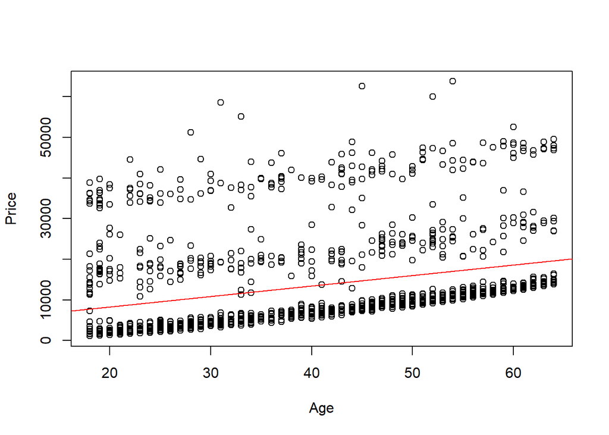

```r
# print scatter plots
plot(insurance$age, insurance$price, ylab = "Price", xlab = "Age")
abline(lm(price ~ age, data = insurance), col = "red")
```

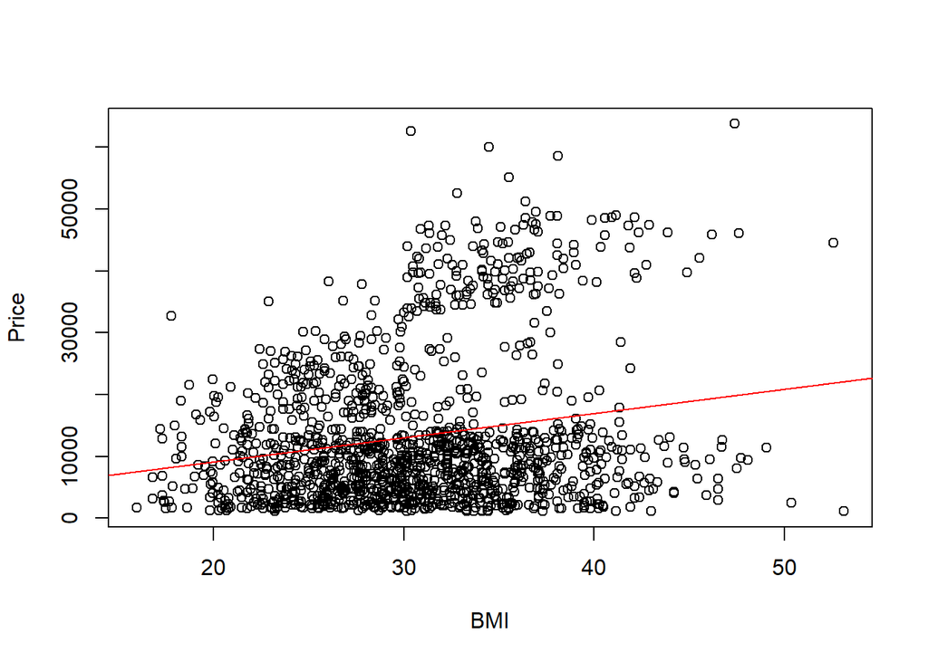

```r
plot(insurance$bmi, insurance$price, ylab = "Price", xlab = "BMI")
abline(lm(price ~ bmi, data = insurance), col = "red")
```

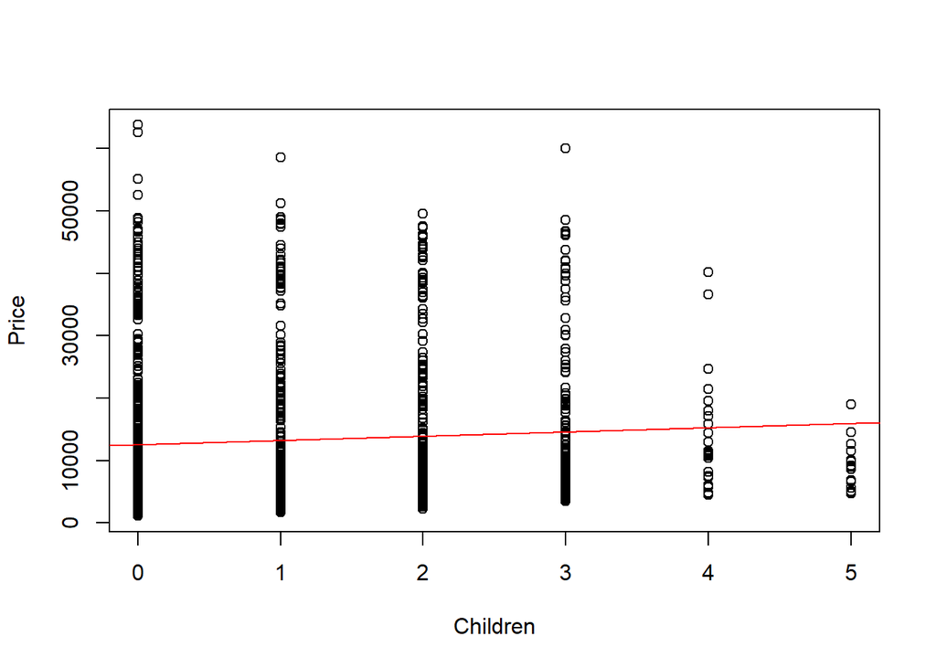

```r
plot(insurance$children, insurance$price, ylab = "Price", xlab = "Children")
abline(lm(price ~ children, data = insurance), col = "red")
```

**Answer:** From the scatterplots above, we can see that there is a positive relationship between $price$ and $age$. These two variables also have the strongest linearity among all the three pairs of variables.

$BMI$ and $price$ also have a generally positive relationship, but the linearity between these two variables is weaker. The variance of $price$ also seems to increase as the value of $BMI$ increases.

There is also a weak positive relationship between $price$ and $children$. But from the scatter plot above, it is had to observe whether these two variables have a linear relationship.

2. **4 pts** What is the value of the correlation coefficient for each of the above pair of response and predictor variables? What does it tell you about your comments in part (a)?

```r
cor(insurance$price, insurance$age)
```

```
## [1] 0.2990082
```

```r
cor(insurance$price, insurance$bmi)
```

```
## [1] 0.198341
```

```r
cor(insurance$price, insurance$children)
```

```
## [1] 0.06799823
```

**Answer:**

The value of correlation between $price$ and $age$ is 0.299

The value of correlation between $price$ and $BMI$ is 0.1983

These correlation values correspond to the comments in part (a) - $price$ and $age$ have the strongest linearity among all the three pairs of variables. The linearity between $price$ and $BMI$ is weaker, and the linearity between $price$ and $children$ is the weakest.

3. **4 pts** Create box plots of the response, *price*, and the three qualitative predictors *sex*, *smoker*, and *region*. Based on these box plots, does there appear to be a relationship between these qualitative predictors and the response?

*Hint*: Use the given code to convert the qualitative predictors to factors.

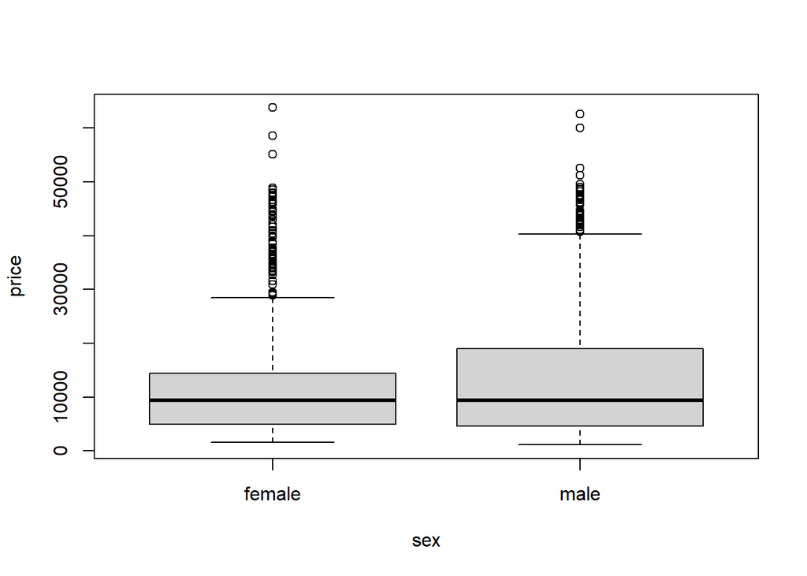

```r
#make categorical variables into factors
insurance$sex<-as.factor(insurance$sex) #makes female the baseline level
insurance$smoker<-as.factor(insurance$smoker) #makes no the baseline level
insurance$region<-as.factor(insurance$region) #makes northeast the baseline level


#create box plots
boxplot(price ~ sex, data = insurance)
```

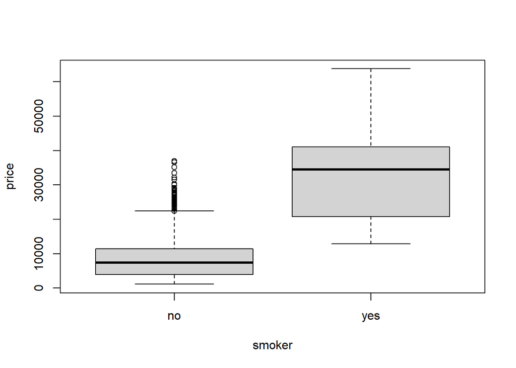

```r
boxplot(price ~ smoker, data = insurance)
```

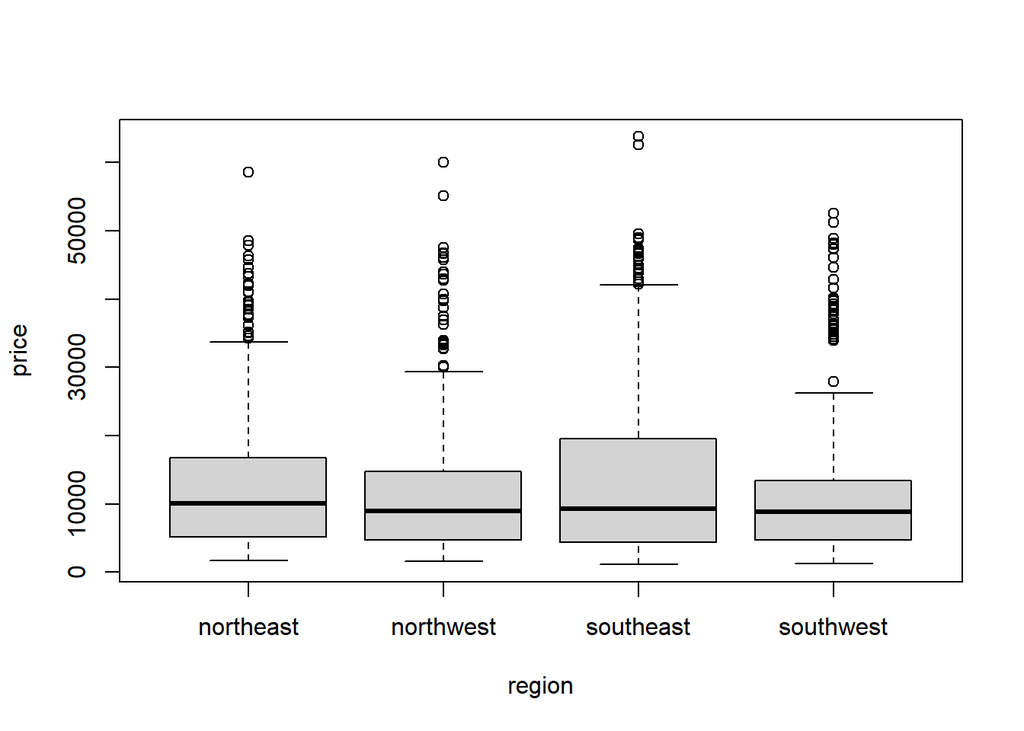

```r
boxplot(price ~ region, data = insurance)
```

**Answer:** From the box plots above, we can not see a obvious difference of $price$ between female and male, or between different regions. But it is obvious that there is a difference of $price$ between smoker and nonsmoker.

Therefore, based on the box plots above, there is a relationship between $price$ and $smoker$. But there is not a relationship between $price$ and $sex$ , or between $price$ and $region$.

4. **3 pts** Based on the analysis above, does it make sense to run a multiple linear regression with all of the predictors?

**Answer:**

Yes, it makes sense to run a multiple linear regression with all the predictors. There are two reasons:

1. From the analysis above, it is clear that there are multiple predictors that may have linear relationship with the response variable, such as $age$ and $smoker$.
2. Even though some predictors seem not to have a linear relationship with the response variable in the analysis above, their relationship with the response variable may change after we include other predictors into the same linear regression model.

# Question 2: Fitting the Multiple Linear Regression Model [12 points]

Build a multiple linear regression model, named *model1*, using the response, *price*, and all 6 predictors, and then answer the questions that follow:

1. **6 pts** Report the coefficient of determination (R-squared) for the model and give a concise interpretation of this value.

```r
model1 <- lm(price ~ ., data = insurance)
summary(model1)
```

```
##
## Call:
## lm(formula = price ~ ., data = insurance)
##
## Residuals:
##      Min       1Q   Median       3Q      Max
## -11304.9  -2848.1   -982.1   1393.9  29992.8
##
## Coefficients:
##                 Estimate Std. Error t value Pr(>|t|)
## (Intercept)     -11938.5      987.8 -12.086  < 2e-16 ***
## age                256.9       11.9  21.587  < 2e-16 ***
## sexmale           -131.3      332.9  -0.394 0.693348
## bmi                339.2       28.6  11.860  < 2e-16 ***
## children           475.5      137.8   3.451 0.000577 ***
## smokeryes        23848.5      413.1  57.723  < 2e-16 ***
## regionnorthwest   -353.0      476.3  -0.741 0.458769
## regionsoutheast  -1035.0      478.7  -2.162 0.030782 *
## regionsouthwest   -960.0      477.9  -2.009 0.044765 *
## ---
## Signif. codes:  0 '***' 0.001 '**' 0.01 '*' 0.05 '.' 0.1 ' ' 1
##
## Residual standard error: 6062 on 1329 degrees of freedom
## Multiple R-squared:  0.7509, Adjusted R-squared:  0.7494
## F-statistic: 500.8 on 8 and 1329 DF,  p-value: < 2.2e-16
```

**Answer:**

The coefficient of determination (R-squared) of the model equals 0.7509

This means that 75.09% of the variations of the response variable ($price$) can be explained by the six predictors in the multiple linear regression model.

2. **6 pts** Is the model of any use in predicting price? Using $\alpha = 0.05$, provide the following elements of the test of overall regression of the model: null hypothesis $H_0$, alternative hypothesis $H_a$, $F$-statistic or $p$-value, and conclusion.

**Answer:**

$H_{0}:$ The coefficients of all the predictors in this model are all zero. ( $\beta_{1}$ = $\beta_{2}$ = … = $\beta_{8}$ = 0 )

$H_{a}:$ The coefficient of at least one predictor in the model is not zero.

$F$ - statistics = 500.8

$p$ - value = 2.2e - 16 (approximately zero)

Since $p$ - value (2.2e - 16) is smaller than $\alpha$ value (0.05), we can reject the null hypothesis and conclude that the coefficient of at least one predictor is different from zero. Therefore, the model is useful in predicting price.

# Question 3: Model Comparison [14 points]

1. **5 pts** Assuming a marginal relationship between *region* and *price*, perform an ANOVA $F$-test on the mean insurance prices among the different regions. Using an $\alpha$-level of 0.05, can we reject the null hypothesis that the means of the regions are equal? Please interpret.

```r
aovmodel <- aov(price ~ region, data = insurance)
summary(aovmodel)
```

```
##               Df    Sum Sq   Mean Sq F value Pr(>F)
## region         3 1.301e+09 433586560    2.97 0.0309 *
## Residuals   1334 1.948e+11 146007093
## ---
## Signif. codes:  0 '***' 0.001 '**' 0.01 '*' 0.05 '.' 0.1 ' ' 1
```

**Answer:**

From the results above, we can see that the p value of the F test equals 0.0309, which is smaller than $\alpha$ (0.05). That means we can reject the null hypothesis and conclude that the mean price of at least one region is different from the mean price of the other regions at an $\alpha$-level of 0.05.

2. **5 pts** Now, build a second multiple linear regression model, called *model2*, using *price* as the response variable, and all variables except *region* as the predictors. Conduct a partial $F$-test comparing *model2* with *model1*. What is the partial-F test p-value? Can we reject the null hypothesis that the regression coefficients for *region* variables are zero at an $\alpha$-level of 0.05?

```r
#build model2
model2 <- lm(price ~ age + sex +bmi + children + smoker, data = insurance)
    #summary(model2)

#perform partial F test
anova(model2, model1)
```

```
## Analysis of Variance Table
##
## Model 1: price ~ age + sex + bmi + children + smoker
## Model 2: price ~ age + sex + bmi + children + smoker + region
##   Res.Df        RSS Df Sum of Sq      F  Pr(>F)
## 1   1332 4.9073e+10
## 2   1329 4.8840e+10  3 233431209 2.1173 0.09622 .
## ---
## Signif. codes:  0 '***' 0.001 '**' 0.01 '*' 0.05 '.' 0.1 ' ' 1
```

**Answer:**

From the results above, we can see that the p value of the partial F test equals 0.09622, which is larger than 0.05 - That means we can not reject the null hypothesis that the regression coefficients for *region* variables are zero at an $\alpha$-level of 0.05.

3. **4 pts** What can you conclude from 3a and 3b? Do they provide the exact same results?

   **Answer:**

   3a and 3b provide different results.

   3a is an ANOVA model that evaluates the relationship between mean $price$ and $region$ without considering other predictors. It shows that the mean insurance prices of different regions are different.

   From the results above we can conclude that the statistical hypothesis test results can be different between a marginal model and a conditional model, even if we are doing tests on the same variables.

*Note: Please use model1 for all of the following questions.*

# Question 4: Coefficient Interpretation [7 points]

1. **3 pts** Interpret the estimated coefficient of *sexmale* in the context of the problem. *Make sure female is the baseline level for sex. Mention any assumptions you make about other predictors clearly when stating the interpretation.*

   ```r
   summary(model1)
   ```

   ```
   ##
   ## Call:
   ## lm(formula = price ~ ., data = insurance)
   ##
   ## Residuals:
   ##      Min       1Q   Median       3Q      Max
   ## -11304.9  -2848.1   -982.1   1393.9  29992.8
   ##
   ## Coefficients:
   ##                 Estimate Std. Error t value Pr(>|t|)
   ## (Intercept)     -11938.5      987.8 -12.086  < 2e-16 ***
   ## age                256.9       11.9  21.587  < 2e-16 ***
   ## sexmale           -131.3      332.9  -0.394 0.693348
   ## bmi                339.2       28.6  11.860  < 2e-16 ***
   ## children           475.5      137.8   3.451 0.000577 ***
   ## smokeryes        23848.5      413.1  57.723  < 2e-16 ***
   ## regionnorthwest   -353.0      476.3  -0.741 0.458769
   ## regionsoutheast  -1035.0      478.7  -2.162 0.030782 *
   ## regionsouthwest   -960.0      477.9  -2.009 0.044765 *
   ## ---
   ## Signif. codes:  0 '***' 0.001 '**' 0.01 '*' 0.05 '.' 0.1 ' ' 1
   ##
   ## Residual standard error: 6062 on 1329 degrees of freedom
   ## Multiple R-squared:  0.7509, Adjusted R-squared:  0.7494
   ## F-statistic: 500.8 on 8 and 1329 DF,  p-value: < 2.2e-16
   ```

**Answer:**

From the results above, we can see that the coefficient of $sexmale$ equals -131.3

This mean that the insurance policy price for male is $131.3 lower on average than the insurance policy price for female, holding all the other predictors constant.

b. **4 pts** If the value of the *bmi* in *model1* is increased by 0.01 and the other predictors are kept constant, what change in the response would be expected?

**Answer:**

Since the coefficient of $bmi$ equals 339.2 , we would expect that $price$ will be increased by $3.392 (339.2 $\times$ 0.01 = 3.392) when $bmi$ is increased by 0.01

# Question 5: Confidence and Prediction Intervals [12 points]

1. **6 pts** Compute 90% and 95% confidence intervals (CIs) for the parameter associated with *age* for *model1*. What observations can you make about the width of these intervals?

```r
# 90% confidence interval
confint(model1, level = 0.9)
```

```
##                         5 %        95 %
## (Intercept)     -13564.4899 -10312.5872
## age                237.2708    276.4419
## sexmale           -679.3429    416.7142
## bmi                292.1187    386.2682
## children           248.6749    702.3262
## smokeryes        23168.4837  24528.5854
## regionnorthwest  -1136.9143    430.9865
## regionsoutheast  -1822.9499   -247.0942
## regionsouthwest  -1746.7292   -173.3728
```

```r
# 95% confidence interval
confint(model1, level = 0.95)
```

```
##                       2.5 %       97.5 %
## (Intercept)     -13876.3934 -10000.68373
## age                233.5138    280.19893
## sexmale           -784.4703    521.84155
## bmi                283.0884    395.29848
## children           205.1633    745.83780
## smokeryes        23038.0307  24659.03838
## regionnorthwest  -1287.2982    581.37040
## regionsoutheast  -1974.0968    -95.94733
## regionsouthwest  -1897.6364    -22.46560
```

**Answer:**

From the results above, we can see that the 90% confidence interval of $age$ is (237.2708 , 276.4419)

and the 95% confidence interval of $age$ is (233.5138 , 280.19893)

The 95% confidence interval is wider than the 90% confidence interval. Since none of the two intervals include 0, we can conclude that the coefficient of $age$ is different from 0 at both 90% level and 95% level.

2. **3 pts** Using *model1*, estimate the average price for all insurance policies with the same characteristics as the first data point in the sample. What is the 95% confidence interval? Provide an interpretation of your results.

```r
# create a new data point with the same characteristics as the first sample
newdata <- insurance[1,]
newdata
```

```
##   age    sex  bmi children smoker    region    price
## 1  19 female 27.9        0    yes southwest 16884.92
```

```r
# calculate the 95% confidence interval
predict(model1, newdata, interval = "confidence", level = 0.95)
```

```
##        fit      lwr      upr
## 1 25293.71 24143.98 26443.44
```

**Answer:**

From the calculations above, the estimated average price for all insurance policies with the same characteristics as the first sample is $25293.71

The 95% confidence interval is (24143.98 , 26443.44). Therefore, we are confident that for all insurance policies with the same characteristics as the first sample, their mean price is 95% likely to fall in this range.

3. **3 pts** Suppose that the *age* value for the first data point is increased to 50, while all other values are kept fixed. Using *model1*, predict the price of an insurance policy with these characteristics. What is the 95% prediction interval? Provide an interpretation of your results.

```r
# create a new data point used for the prediction
newdata2 <- newdata
newdata2$age <- 50
newdata2
```

```
##   age    sex  bmi children smoker    region    price
## 1  50 female 27.9        0    yes southwest 16884.92
```

```r
# Calculate the 95% prediction interval
predict(model1, newdata2, interval = "prediction", level = 0.95)
```

```
##        fit      lwr      upr
## 1 33256.26 21313.29 45199.23
```

**Answer:**

From the calculations above, the predicted price for the insurance policy with this set of characteristics is $33256.26

The 95% prediction interval is (21313.29 , 45199.23). Therefore, we are confident that for each individual insurance policy with the same set of characteristics, its price is 95% likely to fall in this range.